### ESS 575 Models for Ecological Data

#### February 28, 2019

#### Table of Contents

I. Motivation

II. Derived quantities with the logisic

III. Lizards on islands

IV. Guidance

V. References

#### I. Motivation

JAGS allows you to implement models of high dimension once you master its syntax and logic. It is a great tool for ecological analysis. The problems that follow challenge you to:

- Write joint distributions as a basis for writing JAGS code.
- Write JAGS code to approximate marginal posterior distributions of derived quantities.
- Plot model output in revealing ways.
- Understand the effect of vague priors on parameters and on predictions of non-linear models.

#### II. Derived quantities with the logisic

One of the most useful features of MCMC is its equivariance property which means that any quantity that is a function of a random variable in the MCMC algorithm becomes a random variable. Consider two quantities of interest that are functions of our estimates of the random variables $r$ and $K$:

```r
{ # Extra bracket needed only for R markdown files
sink("LogisticJAGS.R")
cat("
model{
  # priors
  K ~ dunif(0, 4000)
  r ~ dunif (0, 2)
  sigma ~ dunif(0, .5)
  tau <- 1/sigma^2

  # likelihood
  for(i in 1:n){
    mu[i] <- r - r/K * x[i]
    y[i] ~ dnorm(mu[i], tau)
  }

  # derived quantities
  # calculate maximum growth rate
  maxdNdt <- K/2
  # calculate growth rate over range of N values. N must be read in as data:
  for (j in 1:length(N)){
    dNdt[j] <- r * N[j] * (1 - N[j]/K)
  }
}
",fill = TRUE)
sink()
} # Extra bracket needed only for R markdown files
```

```r
library(ESS575)
library(rjags)
library(MCMCvis)
library(HDInterval)
set.seed(1)

Logistic <- Logistic[order(Logistic$PopulationSize),]

inits = list(
  list(K = 1500, r = .2, sigma = .01),
  list(K = 1000, r = .15, sigma = .5),
  list(K = 900, r = .3, sigma = .01))

N <- seq(0,1500,10)
N[1] <- 1

data = list(
  n = nrow(Logistic),
  x = as.double(Logistic$PopulationSize),
  y = as.double(Logistic$GrowthRate),
  N = N)

n.adapt = 5000
n.update = 10000
n.iter = 20000

jm = jags.model("LogisticJAGS.R", data = data, inits = inits, n.chains = length(inits), n.adapt = n.adapt)
update(jm, n.iter = n.update)
zm = coda.samples(jm, variable.names = c("K", "r", "sigma", "maxdNdt", "dNdt"), n.iter = n.iter, n.thin = 1)
```

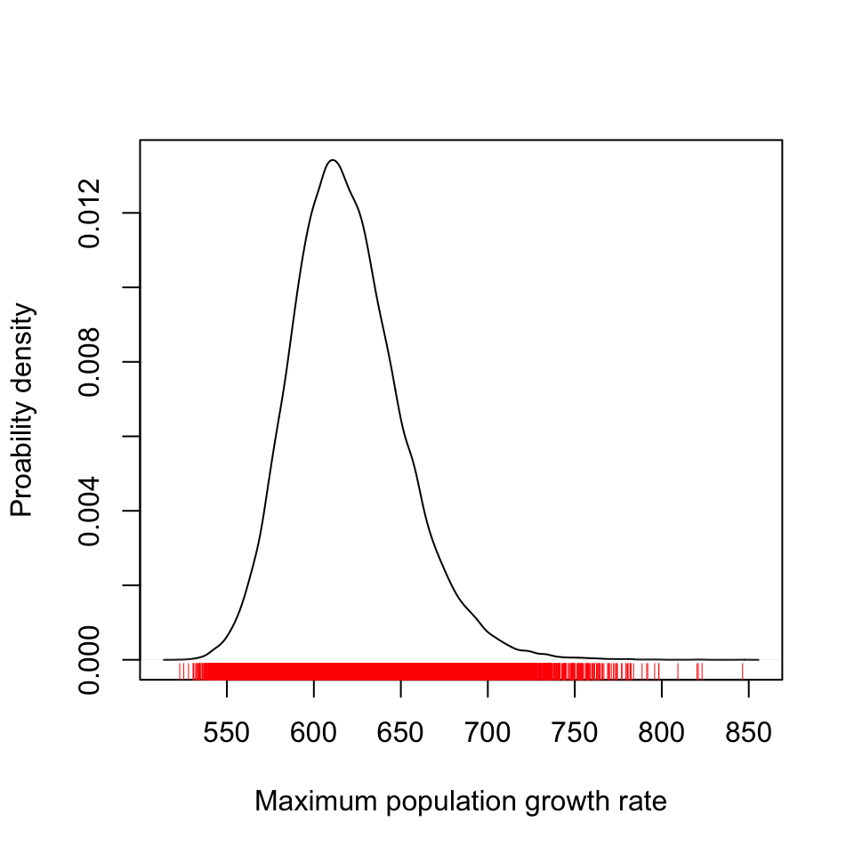

```r
maxdNdt = MCMCchains(zm, params = c("maxdNdt"))
plot(density(maxdNdt), main="", xlab ="Maximum population growth rate", ylab = "Proability density")
rug(maxdNdt, col = "red")
```

2. Plot the median growth rate of the *population* (not the per-capita rate) rate and a 95% highest posterior density interval as a function of $N$. What does this curve tell you about the difficulty of sustaining harvest of populations?

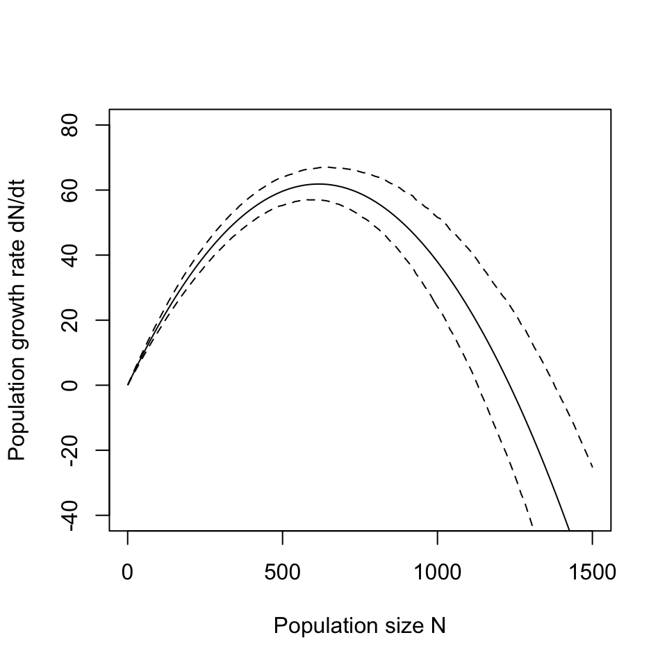

```r
HPDI <-  MCMCpstr(zm, params=c("dNdt"), func = function(x) hdi(x,.95))
medN <- MCMCpstr(zm, params=c("dNdt"), func = median)
plot(N, medN$dNdt,  ylab = "Population growth rate dN/dt", xlab = "Population size N", type = "l", ylim = c(-40, 80))
lines(N, HPDI$dNdt[,1], lty = "dashed")
lines(N, HPDI$dNdt[,2], lty = "dashed")
```

There is far greater uncertainty about the population growth rate when the population is much larger for large populations. It might prove difficult to set a harvest rate that was sustainable in the face of this uncertainty.

3. What is the probability that the intrinsic rate of increase $(r)$ exceeds .22? What is the probability that $r$ falls between .18 and .22?

```r
r = MCMCchains(zm, "r")
1 - ecdf(r)(.22)
```

```
## [1] 0.0233
```

```r
ecdf(r)(.22) - ecdf(r)(.18)
```

```
## [1] 0.9583
```

Some hints:

- Include expressions for each derived quantity in your JAGS code.
- You will need to give JAGS a vector of $N$ values to plot $\frac{dN}{dt}$ vs $N$.
- Use a JAGS object for plotting the rate of population growth.
- Look into using the `ecdf()` function on a JAGS object. It is covered in the JAGS primer.

#### III. Lizards on islands

This problem is courtesy of McCarthy (2007). Polis et al. (1998) analyzed the probability of occupancy of islands $p$ by lizards as a function of the ratio of the islands’ perimeter to area ratios. The data from this investigation are available in the data frame `IslandLizards`. The response data, as you will see, are 0 or 1, 0 if there were no lizards found on the island, 1 if there were 1 or more lizards observed. You are heroically assuming that if you fail to find a lizard, none are present on the island.

1. Construct a simple Bayesian model that represents the probability of occupancy as $g(a,b,x_i)=\frac{e^{a+bx_i}}{1+e^{a+bx_i}}$, where $x_{i}$ is the perimeter to area ratio of the $i^{th}$ island. So, now that you have the deterministic model, the challenge is to choose the proper likelihood to link the data to the model. How do the data arise? What likelihood function is needed to represent the data?

The data arise as presence/absence draws from a Bernoulli distribution whose probability of presence is a function of the perimeter to area ratio as specified above.

2. Write the expression for the posterior and joint distribution of the parameters and data, as we have learned how to do in lecture. Use the joint distribution as a basis for JAGS code needed to estimate the posterior distribution of $a$ and $b$. Assume vague priors on the intercept and slope, e.g., $\beta_0 \sim \text{normal}(0,10000),\, \beta_1 \sim \text{normal}(0,10000)$. Draw a DAG if you like.

There doesn’t appear to be any variance term in this model. How can that be?

$$\begin{align}
\big[a, b \mid \textbf{y}\big] & \propto
\prod_{i = 1}^{19}\textrm{Bernoulli}\big(y_{i}\mid g(a,b,x_i)\big)\,\textrm{normal}\big(a\mid,0,10000\big)
\textrm{normal}\big(b\mid 0,10000\big)\\\
p&=g(a,b,x_i) = \textrm{inverse logit}\big(a + bx_{i}\big) = \frac{\exp{\big(a + bx_{i}\big)}}{1+\exp\big(a + bx_{i}\big)}
\end{align}$$

The variance of a Bernoulli distribution is $p(1-p)$. It is implicit in the model in the same way that variance is implicit in the Posisson distribution.

```r
{ # Extra bracket needed only for R markdown files
sink("IslandJAGS.R")
cat("
model{
# priors
  a ~ dnorm(0, 1.0E-6)
  b ~ dnorm(0, 1.0E-6)

# likelihood
  for (i in 1:n){
    logit(p[i]) <- a + b*x[i]
    y[i] ~ dbern(p[i])
  }

} #end of model
",fill = TRUE)
sink()
} # Extra bracket needed only for R markdown files
```

3. Using JAGS, run MCMC for three chains for the parameters $a$ and $b$ and the derived qauntity $p_i$, the probability of occupancy. JAGS has a function, `ilogit` for the inverse logit that you might find helpful.

Selecting initial conditions can be a bit tricky with the type of likelihood you will use here. You may get the message “Error in jags.model(”IslandsJags.R“, data = data, inits, n.chains = length(inits), : Error in node y[4] Observed node inconsistent with unobserved parents at initialization”. To overcome this, try the following:

- Standardize the the perimeter to area ratio covariate using the `scale` function in R, which subracts the mean of the data from every data point and divides by the standard deviation of the data. You want the default arguemtns for `center` and `scale` in this function.
- Choose initial values for $a$ and $b$ so that $\textrm{inverse logit}\big(a + b\,\text{standardized}(x_{i})\big)$ is between .01 and .99.

```r
library(ESS575)
library(rjags)
set.seed(1)

inits = list(
  list(a = runif(1, -2, 2), b = runif(1, -2, 2)),
  list(a = runif(1, -2, 2), b = runif(1, -2, 2)),
  list(a = runif(1, -2, 2), b = runif(1, -2, 2)))

data = list(
  n = nrow(IslandLizards),
  x = as.double(scale(IslandLizards$perimeterAreaRatio)),
  y = as.double(IslandLizards$presence))

n.adapt = 5000
n.update = 10000
n.iter = 10000

jm = jags.model("IslandJAGS.R", data = data, inits = inits, n.chains = length(inits), n.adapt = n.adapt)
update(jm, n.iter = n.update)
zm = coda.samples(jm, variable.names = c("a", "b"), n.iter = n.iter, n.thin = 1)
```

4. Do a summary table, a plot of the marginal posterior densities of of the posterior density and a trace of the chain for parameters $a$ and $b$. Does the trace indicate convergence? How can you tell? Use Gelman and Heidel diagnostics to check for convergence.

```r
MCMCsummary(zm)
```

```
##         mean        sd      2.5%        50%      97.5% Rhat
## a -0.6827988 0.8434291 -2.504951 -0.6255668  0.8257758    1
## b -4.9508809 2.1289695 -9.898807 -4.6662807 -1.6399929    1
```

```r
MCMCtrace(zm)
gelman.diag(zm, multivariate = FALSE)
```

[output not shown]

```
## Potential scale reduction factors:
##
##   Point est. Upper C.I.
## a          1          1
## b          1          1
```

```r
heidel.diag(zm)
```

```
## [[1]]
##
##   Stationarity start     p-value
##   test         iteration
## a passed       1         0.139
## b passed       1         0.970
##
##   Halfwidth Mean   Halfwidth
##   test
## a passed    -0.693 0.0280
## b passed    -4.987 0.0767
##
## [[2]]
##
##   Stationarity start     p-value
##   test         iteration
## a passed       1         0.910
## b passed       1         0.652
##
##   Halfwidth Mean   Halfwidth
##   test
## a passed    -0.678 0.0260
## b passed    -4.940 0.0737
##
## [[3]]
##
##   Stationarity start     p-value
##   test         iteration
## a passed       1         0.850
## b passed       1         0.599
##
##   Halfwidth Mean   Halfwidth
##   test
## a passed    -0.677 0.0258
## b passed    -4.926 0.0718
```

5. Plot the data as points. Overlay a line plot of the median and 95% highest posterior density intervals of the predicted probability of occurrence as a function of island perimeter to area ratios ranging from 1-60. Hint–create a vector of 1-60 in R, and use it as $x$ values for an equation making predictions in your JAGS code. Use a JAGS object for plotting. This makes a nice smooth curve. The curve is jumpy if you simply plot the predictions at the island perimeter to area data points. Remember, however, that the x’s have been standardized to fit the coefficients, so you need to make predictions usig standardized values in the sequence you create. You may plot these predictions against the undsandardized perimeter to area ratios, a plot that is more easily interpreted than plotting against the standardized ratios.

```r
{ # Extra bracket needed only for R markdown files
sink("IslandJAGS.R")
cat("
model{
# priors
  a ~ dnorm(0, 1.0E-6)
  b ~ dnorm(0, 1.0E-6)

# likelihood
  for (i in 1:n){
    logit(p[i]) <- a + b*x[i]
    y[i] ~ dbern(p[i])
  }

# derived quantities
  for (j in 1:length(PA)){
    pHat[j] <- ilogit(a + b*PA[j])
  }

} #end of model
",fill = TRUE)
sink()
} # Extra bracket needed only for R markdown files
```

```r
inits = list(
  list(a = runif(1, -2, 2), b = runif(1, -2, 2)),
  list(a = runif(1, -2, 2), b = runif(1, -2, 2)),
  list(a = runif(1, -2, 2), b = runif(1, -2, 2)))

x <- scale(IslandLizards$perimeterAreaRatio)
mu.PA = mean(IslandLizards$perimeterAreaRatio)
sd.PA = sd(IslandLizards$perimeterAreaRatio)
#mu <- attr(x, "scaled:center")
#sd <- attr(x, "scaled:scale")
PA <- (seq(1,60,.5) - mu.PA)/sd.PA  #This is a sequence useful for plottig

data = list(
  n = nrow(IslandLizards),
  x = as.double(x),
  y = as.double(IslandLizards$presence),
  PA = as.double(PA))

n.adapt = 5000
n.update = 10000
n.iter = 10000

jm = jags.model("IslandJAGS.R", data = data, inits = inits, n.chains = length(inits), n.adapt = n.adapt)
update(jm, n.iter = n.update)
zm = coda.samples(jm, variable.names = c("pHat"), n.iter = n.iter, n.thin = 1)
```

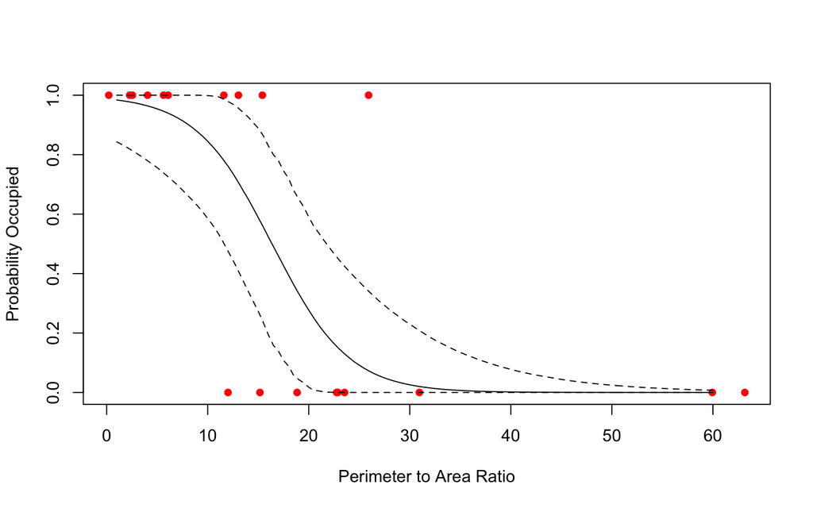

```r
pHat = MCMCpstr(zm, params = "pHat", func = median)
pHPDI = MCMCpstr(zm, params = "pHat", func = function(x) hdi(x,.95))
plot(IslandLizards$perimeterAreaRatio, IslandLizards$presence, xlab = "Perimeter to Area Ratio", ylab = "Probability Occupied", pch = 16, col = "red")
lines(seq(1,60,.5), pHat$pHat, type = 'l')
lines(seq(1,60,.5), pHPDI$pHat[,1], lty = "dashed")
lines(seq(1,60,.5), pHPDI$pHat[,2], lty = "dashed")
```

6. Assume you are interested in 2 islands, one that has a perimeter to area ratio of 10, the other that has a perimeter to area ratio of 20. What is the 95% highest posterior density interval on the difference in the probability of occupancy of the two islands based on the analysis you did above? What is the probability that the difference exceeds 0? Remember that the data are standardized when you do this computation.

```r
{ # Extra bracket needed only for R markdown files
sink("IslandJAGS.R")
cat("
model{
# priors
  a ~ dnorm(0, 1.0E-6)
  b ~ dnorm(0, 1.0E-6)

# likelihood
  for (i in 1:n){
    logit(p[i]) <- a + b*x[i]
    y[i] ~ dbern(p[i])
  }

# derived quantities
  for (j in 1:length(PA)){
    pHat[j] <- ilogit(a + b*PA[j])
  }

  p10 <- exp(a + b*(10 - mu)/sd) / (1 + exp(a + b*(10 - mu)/sd))
  p20 <- exp(a + b*(20 - mu)/sd) / (1 + exp(a + b*(20 - mu)/sd))
  diff <- p10 - p20

} #end of model
",fill = TRUE)
sink()
} # Extra bracket needed only for R markdown files
```

```r
#note the scaling functions for x and PA above
data = list(
  n = nrow(IslandLizards),
  x = as.double(x),
  y = as.double(IslandLizards$presence),
  PA = as.double(PA),
  mu = mu.PA,
  sd = sd.PA)

jm = jags.model("IslandJAGS.R", data = data, inits = inits, n.chains = length(inits), n.adapt = n.adapt)
update(jm, n.iter = n.update)
zm = coda.samples(jm, variable.names = c("diff", "pHat"), n.iter = n.iter, n.thin = 1)
diff = MCMCchains(zm, params = "diff")
print("HPDI on difference in probability of occupancy")
```

```
## [1] "HPDI on difference in probability of occupancy"
```

```r
hdi(diff, .95)
```

```
##            diff
## lower 0.2038453
## upper 0.8599730
## attr(,"credMass")
## [1] 0.95
```

```r
p_diff_gt_0=1-ecdf(diff)(0)
print("P(difference > 0")
```

```
## [1] "P(difference > 0"
```

```r
p_diff_gt_0
```

```
## [1] 1
```

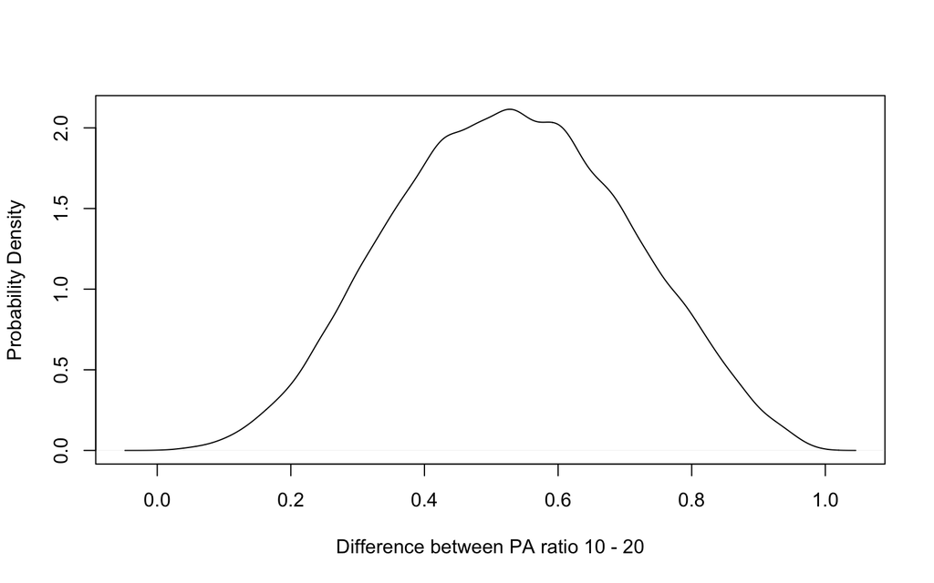

```r
plot(density(diff), main = "", xlab = "Difference between PA ratio 10 - 20", ylab = "Probability Density")
```

7. What fundamentally important source of error are we sweeping under the rug in all of these fancy calculations? What are the consequences of failing to consider this error for our estimates? Do you have some ideas about how we might cope with this problem?

The priors you chose above were vague for the intercept and slope in the logistic regression but they were *not* vague for $p_{i}$. This is generally true for the output of nonlinear functions like the inverse logit (Lunn et al., 2012; Seaman et al., 2012), so you need to be careful about inference on the output of these non-linear function. See Hobbs and Hooten (2015) section 5.4.1 for an explanation of priors in logistic regression. It is prudent to to explore the effect of different values for priors on the shape of a the “prior” for quantities that are non-linear functions of model parameters, as demonstrated in the following exercise